# Big data in Sport Industry Project

Ku, Bonseong

2019년 5월 29일

# 패키지, 데이터 불러오기

```r
library(ggplot2)
library(ggwordcloud)
```

1. 알버트 아인슈타인(Albert Einstein)의 “Relativity: The Special and General Theory” : 상대성이론 제시
2. 갈릴레오 갈릴레이(Galileo Galilei)의 “Discourse on Floating Bodies” : 당시 유행하던 구시대의 아리스토텔레스 관점의 물리학 논파
3. 크리스티안 호이겐스(Christiaan Huygens)의 “Treaties on Light” : 빛의 굴절에 관한 이론 제시
4. 니콜라 테슬라(Nicola Tesla)의 “Experiment with Alternate Currents of High Potential and High Frequency” : 토마스 에디슨의 직류전기보다 안전한 교류전기의 유용성 및 안정성을 강조

```r
#einstein <- scan( "http://www.gutenberg.org/files/5001/5001-h/5001-h.htm" , what = character() )
galilei <- scan( "http://www.gutenberg.org/cache/epub/37729/pg37729.txt" , what = character() )
huygens <- scan( "http://www.gutenberg.org/cache/epub/14725/pg14725.txt" , what = character() )
tesla <- scan( "http://www.gutenberg.org/cache/epub/13476/pg13476.txt" , what = character() )

einstein <- scan( "./pg5001.txt" , what = character() )
#galilei <- scan( "pg37729.txt" , what = character() )
#huygens <- scan( "pg14725.txt" , what = character() )
#tesla <- scan( "pg13476.txt" , what = character() )
```

# 의미 없는 단어 제거

여기에서 영어권에서 흔히 쓰이는 구두점(punctuation) 및 띄어쓰기, 줄내림을 의미하는 `\n` 표기 등을 원문으로부터 제거하고 사용된 모든 단어들을 낱개로 나누어 다음과 같이 `tmp_xxxx`로 옮겨 놓았다. 그럼에도 깨끗하게 처리되지 않았음을 알 수 있으며, 이는 향후 분석에 영향을 주지 않을 것이다.

```r
remove_punct <- function( str ) {
    tmp <- gsub( "[[:punct:][:blank:]]+" , "" , str )
    tmp <- unlist( apply( as.matrix( tmp ) , c(1,2) , strsplit , split = "\n" ) )
    tmp <- tmp[ tmp != "" ]
    res <- tolower( tmp )
    return( res )
}

tmp_einstein <- remove_punct( einstein )
tmp_galilei <- remove_punct( galilei )
tmp_huygens <- remove_punct( huygens )
tmp_tesla <- remove_punct( tesla )
```

```r
length( tmp_einstein ); head( tmp_einstein , 20 )
```

```
## [1] 27038
```

```
##  [1] "癤풲he"     "project"    "gutenberg"  "ebook"      "of"
##  [6] "relativity" "the"        "special"    "and"        "general"
## [11] "theory"     "by"         "albert"     "einstein"   "1"
## [16] "in"         "our"        "series"     "by"         "albert"
```

```r
length( tmp_galilei ); head( tmp_galilei , 20 )
```

```
## [1] 41952
```

```
##  [1] "癤풮roject" "gutenbergs" "discourse"  "on"         "floating"
##  [6] "bodies"     "by"         "galileo"    "galilei"    "this"
## [11] "ebook"      "is"         "for"        "the"        "use"
## [16] "of"         "anyone"     "anywhere"   "at"         "no"
```

```r
length( tmp_huygens ); head( tmp_huygens , 20 )
```

```
## [1] 41130
```

```
##  [1] "癤풲he"     "project"    "gutenberg"  "ebook"      "treatise"
##  [6] "on"         "light"      "by"         "christiaan" "huygens"
## [11] "translated" "by"         "silvanus"   "p"          "thompson"
## [16] "this"       "ebook"      "is"         "for"        "the"
```

```r
length( tmp_tesla ); head( tmp_tesla , 20 )
```

```
## [1] 42192
```

```
##  [1] "癤풲he"      "project"     "gutenberg"   "ebook"       "experiments"
##  [6] "with"        "alternate"   "currents"    "of"          "high"
## [11] "potential"   "and"         "high"        "frequency"   "by"
## [16] "nikola"      "tesla"       "this"        "ebook"       "is"
```

# 텍스트 마이닝

해당 논문들은 4명의 저자의 각자 전문성을 나타내는 글이다. 논문에 사용된 단어만을 이용해 각 논문의 내용이 어떤 종류의 글인지 파악하는 것이 목적이다.

TF-IDF(Term Frequency - Inverse Document Frequency)는 정보 검색과 텍스트 마이닝에서 이용하는 가중치로, 여러 문서로 이루어진 문서군이 있을 때 어떤 단어가 특정 문서 내에서 얼마나 중요한 것인지를 나타내는 통계적 수치이다. 문서의 핵심어를 추출하거나, 검색 엔진에서 검색 결과의 순위를 결정하거나, 문서들 사이의 비슷한 정도를 구하는 등의 용도로 사용할 수 있다.

이 가중치를 이용하여 각 단어에 중요하다고 판단하는 단어에 가중치를 두기로 하고, 에세이를 분석했다.

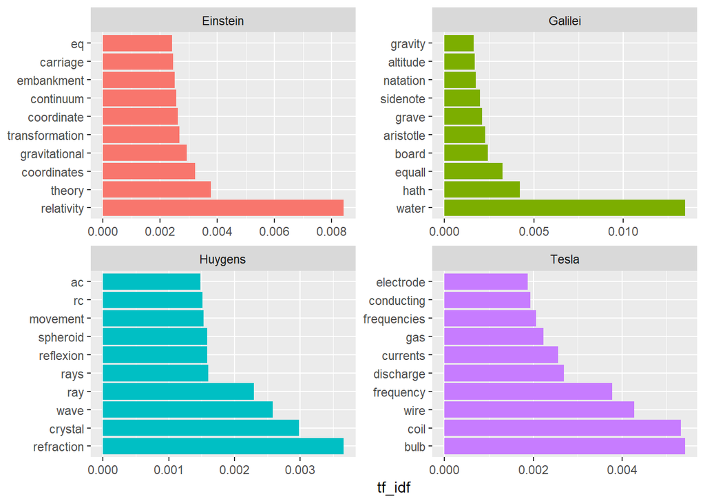

```r
tab_einstein <- table( tmp_einstein ) ; tab_einstein <- sort( tab_einstein , decreasing = TRUE )
tab_galilei <- table( tmp_galilei ) ; tab_galileo <- sort( tab_galilei , decreasing = TRUE )
tab_huygens <- table( tmp_huygens ) ; tab_huygens <- sort( tab_huygens , decreasing = TRUE )
tab_tesla <- table( tmp_tesla ) ; tab_tesla <- sort( tab_tesla , decreasing = TRUE )

author <- rep( c( "Einstein" , "Galilei" , "Huygens" , "Tesla" ) , c( length( tab_einstein ) , length( tab_galilei ) , length( tab_huygens ) , length( tab_tesla ) ) )
word <- c( names( tab_einstein ) , names( tab_galilei ) , names( tab_huygens ) , names( tab_tesla ) )
count <- c( tab_einstein , tab_galilei , tab_huygens , tab_tesla )

tf_einstein <- tab_einstein / sum( tab_einstein )
tf_galilei <- tab_galilei / sum( tab_galilei )
tf_huygens <- tab_huygens / sum( tab_huygens )
tf_tesla <- tab_tesla / sum( tab_tesla )
tf <- c( tf_einstein , tf_galilei , tf_huygens , tf_tesla )

physics <- data.frame( author = author , word = word , count = count , tf = tf , stringsAsFactors = FALSE )

idf_fun <- function( word ) {
    idx <- physics$word %in% word
    idf <- log( 4 / sum(idx) )
    return( idf )
} #tf_idf 가중치 함수 설정

idf <- sapply( physics$word , FUN = idf_fun )

physics$idf <- idf
physics$tf_idf <- physics$tf * physics$idf

idx <- tapply( physics$tf_idf , physics$author , FUN = order , decreasing = TRUE )

tf_idf_einstein <- physics[ physics$author == "Einstein" , ][ idx$Einstein[1:10] ,]
tf_idf_galilei <- physics[ physics$author == "Galilei" , ][ idx$Galilei[1:10] ,]
tf_idf_huygens <- physics[ physics$author == "Huygens" , ][ idx$Huygens[1:10] ,]
tf_idf_tesla <- physics[ physics$author == "Tesla" , ][ idx$Tesla[1:10] ,]

physics <- rbind( tf_idf_einstein , tf_idf_galilei , tf_idf_huygens , tf_idf_tesla )

p <- ggplot( physics , aes( x = factor(word , levels = word ) , y = tf_idf , fill = author ) ) + geom_col( show.legend = FALSE )
p + facet_wrap( ~ author , scales = "free" ) + coord_flip() + theme( axis.title.y = element_blank() )
```